# Hunting skills and ethnobiological knowledge among the young, educated Papua New Guineans: Implications for conservation - ScienceDirect

## [Global Ecology and Conservation](https://www.sciencedirect.com/journal/global-ecology-and-conservation)

Available online 13 March 2023, e02435

# Hunting skills and ethnobiological knowledge among the young, educated Papua New Guineans: Implications for conservation

Under a Creative Commons [license](http://creativecommons.org/licenses/by-nc-nd/4.0/)

open access

## Abstract

Hunting, as a component of traditional indigenous livelihoods, can play either positive or negative role in biodiversity conservation by maintaining traditional lifestyles that are conducive to conservation or by endangering vulnerable hunted species. Quantitative data on changes in hunting skills in indigenous communities driven by education, employment, and other lifestyle changes are lacking. Here we assess hunting skills of young people in Papua New Guinea (PNG). We use a sample of 7,818 secondary school students, representing 15% of the most educated individuals in their age cohort. Students self-assessed their hunting skills as none (34% of respondents), poor (46%), and good (20%). Male students reported significantly higher hunting skills than female students. Hunting skills were positively correlated with knowledge of local bird species and with other traditional skills (growing food, using medicinal plants, building houses). They were negatively correlated with math and English skills, as well as with the transportation accessibility of the village/town where the students grew up. Students who grow up in town reported significantly lower hunting skills than those who grew up in village. These results show that students' hunting skills are already low, and the trends in their socio-cultural drivers predict a further decline in the future. The increasing disconnection from the natural environment and the declining attractiveness of hunting as prestigious activity for the young and educated people are part of a broader trend of loss of ethnobiological knowledge in PNG's indigenous communities. While it may reduce hunting pressure on some endangered species, it may also remove traditional incentives for conservation in rainforest-dwelling communities.

## Keywords

Biodiversity conservation

ethnobiological knowledge

hunting skills

education

indigenous communities

tropical forests

## 1. Introduction

### 1.1. The benefits of hunting

Hunting plays numerous roles in the indigenous communities of rainforest dwellers in the tropics. It is a part of cultural heritage, a way to enhance personal prestige, a source of food, raw materials, and trophies, a source of income, and a sport and leisure activity (Brashares et al., 2011, Luz et al., 2017, Milner-Gulland and Bennett, 2003, Nielsen et al., 2018). A conservative projection by Nielsen et al. (2018) indicates that more than 150 million households in Latin America, Asia, and Africa rely to some extent on wild meat for subsistence or as a source of income. Although hunting is widespread in agricultural rural communities, it generally accounts for a relatively small portion of income and diet. This is the case in rainforest communities from PNG (Mack and West, 2005) or the Yanomamo from the Amazon who spend as much time hunting as growing food in their gardens, although the gardens provide 80-90% of their food (Chagnon, 2012). However, the extent of hunting and its benefits may vary across countries (Nielsen et al., 2017, Nielsen et al., 2018).

PNG has high forest cover, 78% of the land area (Gamoga et al., 2021), low population density of 20 persons per km<sup>2</sup>, and a predominantly rural population, with 87% of the population living in villages (Worldometers, 2020). The diversity and biomass of larger animals that can be hunted for food is low in New Guinea's marsupial-dominated forests (Cuthbert, 2010, Mack and West, 2005). Hence, Mack and West (2005) argue that hunted animals in PNG should be referred to as "wild meat" because there is little or no market for it and the animals are killed mainly for consumption by the hunter and his family, as opposed to game or "bushmeat" where the hunted animals are killed to generate income. Demand for wild meat from urban populations is also limited (Mack & West, 2005). Culturally important species such as cassowaries, crocodiles, pythons, and tree kangaroos are used to pay bride prices or for other traditional payments (Mack and West, 2005, Saulei and Aruga, 1994). A greater number of species are hunted to be used as trophies, and as ornaments and to obtain materials for costumes for traditional dances and ceremonies (Supuma, 2018).

### 1.2. Increasing hunting pressure in PNG

Traditional hunting in PNG has often been made sustainable through a combination of taboo forest areas or taboo hunting seasons with inefficient hunting techniques, usually using bows and arrows (Supuma, 2018). Many conservation-friendly traditional practices are grounded in traditional belief systems (West & Brockington, 2006) but may no longer be observed or effective due to cultural change, including the spread of Christianity in PNG (Jacka, 2010, Raymond, 2007, Robbins, 1995, Smith and Wishnie, 2000).

Hunting in PNG may already be unsustainable in many places or is becoming so due to increased hunting pressure from a rapidly growing population (Cuthbert, 2010, Mack and West, 2005, Nugi and Whitmore, 2020). Lifestyle changes in PNG are accompanied by unprecedented population growth of >2% per year, which has tripled the population over the past 50 years (Worldometers, 2020). These changes may alter the way wildlife are used and managed and threaten some hunted species (Godoy et al., 2005, Shen et al., 2012). Fortunately, hunting methods remain largely traditional, without the use of firearms that is common in many other countries. In the absence of large animals that can be hunted for wild meat, with the important exception of introduced wild pigs (Ayalew et al., 2011), a few larger species such as tree kangaroos and cassowaries, as well as long-billed echidnas, cuscuses, wallabies, ringtails, and others, could be hunted to local extinction (Cuthbert, 2010). The effects of hunting may be exacerbated by low reproductive rates of the long-beaked echidna, tree kangaroos, cuscuses, and other marsupial species (Cuthbert, 2010).

With over 97% of PNG's indigenous population owning land (Armitage, 2001), there is virtually no government control over hunting, even in protected areas. The Faunal Act of 1996 lists protected bird and mammal species, including all birds of paradise and tree kangaroo (*Dendrolagus*) species, but lacks a system of enforcement and monitoring (Shearman & Bryan, 2015).

### 1.3. *Lifestyle changes divert interest in hunting*

Changing lifestyles, including new employment opportunities (Gill et al., 2012) or the introduction of alternative sources of income, such as growing coffee, vanilla, or other cash crops, may reduce the attractiveness of hunting (Sirén and Parvinen, 2015, Vasco and Sirén, 2016), which can be perceived as laborious and unprofitable by comparison (Williams & Knight, 2021). Conservation projects can introduce alternative sources of meat or income to achieve a reduction in hunting activities (Williams & Knight, 2021).

Hunting skills are often replaced by educational achievement as a source of personal prestige in rural communities (Luz, 2015). Hunting as a source of entertainment increasingly competes with sports, such as football and rugby, and with online entertainment. This is fueled by the expansion of mobile phone signal coverage (Foster & Horst, 2018). These factors may be exacerbated by urbanization, as well as increased accessibility of village communities through the expanding road network (Gray et al., 2015, Vasco and Sirén, 2016). Loss of regular contact with the natural environment and loss of traditional ecological knowledge, including detailed information on wildlife ecology, may lead to abandonment of hunting but also make traditional habitat management and wildlife conservation less effective (Aswani et al., 2018, Kik et al., 2021). For example, traditional knowledge of bird taxonomy, ecology, and behavior may be useful for both hunting and conservation management.

Given the ambiguous relationship between hunting and nature conservation, the ongoing change of the way of life of indigenous peoples in PNG can have either negative or positive effect on the survival of hunted species. Therefore, it is important to quantify the extent of that change, especially among the younger people, and to examine the relationship between hunting and ethnobiological knowledge. At present, there is only one quantitative study of hunting sustainability in PNG (Cuthbert, 2010) and a few anthropological studies of individual rural communities (Bergh et al., 2013, Williams and Knight, 2021, Mack and West, 2005, Nugi and Whitmore, 2020, Sillitoe, 2001). In order to fill this knowledge gap, we conducted a countrywide survey among young, educated Papua New Guineans. We aim to (1) assess their self-reported hunting skills, (2) assess socio-cultural drivers of hunting skills, and (3) investigate the relationship between hunting skills and ethnobiological knowledge as well as other traditional skills.

## 2. Materials and methods

### 2.1. Student survey

We conducted a survey that included sociodemographic characteristics, family background, level of language proficiency, traditional skills including hunting, and ethnobiological knowledge of secondary school students (grades 11 and 12, i.e., two senior years in the 4-year secondary education) in PNG. The survey was conducted in English, the official language of education, from 14 April 2015 to 14 November 2018. It included thirty rural and urban secondary schools (24% of the country's total) representing a culturally diverse sample of students speaking 392 languages from all of PNG's provinces (Fig. 1 *R*). Students were gathered in a common room (e.g., a dining hall) where they completed the questionnaire anonymously within one hour (Fig. 1 *L*). Students received small gifts such as pens for their participation. Although participation was voluntary, all students took the survey, which minimized the risk of bias among students with lower interest in hunting who might not want to participate in other settings. The survey was approved by the Education Departments of the Provincial Governments and the Institutional Review Board of the New Guinea Binatang Research Center (BRC_03_15/01/2015). All participants provided informed consent before participating in the survey.

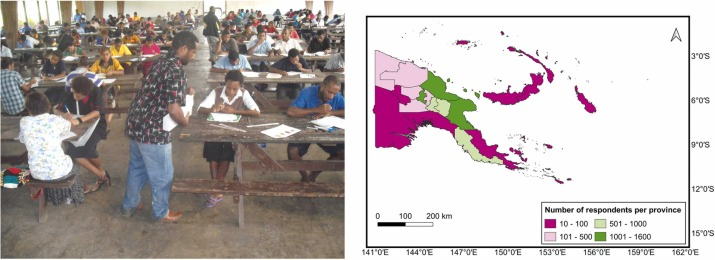

Fig. 1. Ethnobiological skills test administered at Brahman secondary school in 2015 (*L*) and PNG map showing the number of students surveyed (*R*).

### 2.2. Variable choice

We used selected questions from a comprehensive questionnaire (Document S1) to examine the hunting skills of students and their drivers. The dependent variable "hunting skills" was based on the question "Do you know how to hunt animals in the forest?", which was a Likert-type item scored on a three-point scale (0 “no hunting skills”, 1 “poor hunting skills”, 2 “good hunting skills”) (Table S3). Similarly scored responses to questions about skills in fishing, growing food, building a house from traditional forest materials, and treating fever with medicinal plants were combined into a single continuous predictor variable called *traditional skills*. Here we have taken the sum of the scores of each traditional skill listed above for each respondent. Other predictor variables were *gender* (male or female), *urbanization*, i.e., where the student lived during childhood, coded as village (1) or town or city (2), *remoteness*, i.e., whether the student's home was accessible by road (1), only by boat (2), only by plane (3), or only on foot (4), *parental education*: the highest education attained by a parent is reported as no school (1), lower primary (first through sixth grades) (2), higher primary (seventh through eighth grades) (3), lower secondary (9th through 10th grades) (4), higher secondary (11th through 12th grades) (5), or any tertiary education (6), *parents' employment*: the highest employment category attained by a parent is reported as subsistence farming (1), cash crop farming (2), or salaried job or small business (3) were averaged into a single continuous variable, *modern skills*: the students' skills in using the telephone and computer were averaged into a single continuous variable, and students' lower secondary (grade 10) *math and English scores*, distinction (1), credit (2), upper pass (3), and pass or fail (4), were averaged into a single continuous variable.

Students also identified two groups of 10 bird species that are geographically widespread, one from montane regions and one from lowland regions, in their local language. Each group included a range of species that are widely known and easily recognized (e.g., cassowary), as well as species that are difficult to identify. For each student, the higher value of the two species groups was used to minimize bias due to the student's region of origin.

### 2.3. Statistical analysis

We tested the drivers of hunting skills, using the variables described in the above section as predictors. Our analysis requires ordinal approaches, namely logistic regressions, due to the non-linear and ordered nature of the dependent variable. Because the proportionality assumption (the Brant test) for gender was violated (Table S1), we used a partial proportional odds model to examine the explanatory variables associated with hunting skill ratings (Peterson & Harrell Jr., 1990). The vglm function from the VGAM package was used to estimate the model (Yee, 2010). Each variable was normalised before fitting the model. Odds ratio estimates (OR) and 95% confidence intervals (CIs) were used to interpret the results (Sengeh et al., 2020, Suri et al., 2019). The analysis yielded two odds ratios for the gender variable (none vs. poor/good [OR<sub>1</sub>] and none/poor vs. good [OR<sub>2</sub>]) due to violation of the proportional odds assumption (Williams, 2006). For the variables that did not violate the assumption, a single OR was reported. A p-value of < 0.05 was defined as statistically significant for all tests. We performed model selection to determine the best-fitting combinations of explanatory variables using the Akaike Information Criterion (AIC). We intentionally omitted interactions to avoid inflation in the number of models considered and to limit the degrees of freedom in the models. The simplest model with the lowest ∆AIC was selected for the report (Burnham & Anderson, 2004) (Table S2). The data used for the analysis can be found in Supporting Information Dataset S1. All analyses were performed in R version 4.0.5 (R Core Team, 2021).

## 3. Results

We sampled 8,708 participants but excluded 890 (10.2%) partially completed questionnaires with missing values. The remaining 7,818 respondents were used for analysis. They were 58.1% male and 41.9% female, with an average age of 19 years. Overall, 33.9% of the students reported no hunting skills, 45.8% reported poor hunting skills, and 20.3% reported good hunting skills (Table 2).

Male students reported significantly higher hunting skills as well as better knowledge of bird and other traditional skills than female students (Fig. 2, Table 1 – 2, S4).

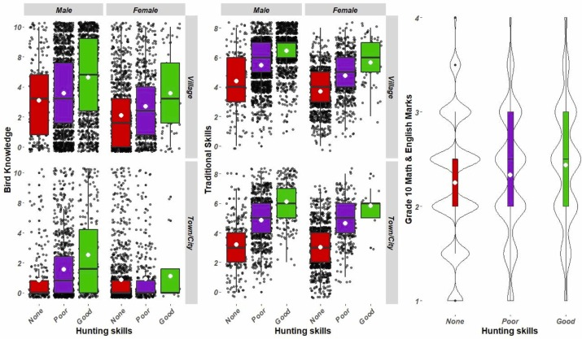

Fig. 2. Bird knowledge (*L*) and traditional skills (*C*) at different levels of hunting skills, broken down by gender and urbanization. *R*: Grade 10 proficiency (1 - 4, from best to worst) for different levels of hunting skills. Data points (individual students) added to boxplots (median with 1<sup>st</sup> and 3<sup>rd</sup> quartiles, mean marked by a white circle).

Table 1. Results of the partial proportional odds model: factors influencing hunting skills.

| **Predictor** | **OR (CI)** | **P-value** |
| --- | --- | --- |
| Urbanization | 0.71 (0.63 - 0.79) | <0.001 |
| Remoteness | 1.11 (1.05 - 1.16) | <0.001 |
| Bird knowledge | 1.34 (1.26 - 1.40) | <0.001 |
| Traditional skills | 3.10 (2.89 - 3.29) | <0.001 |
| Grade 10 marks | 1.08 (1.03 - 1.14) | 0.002 |
| Gender |  |  |
| OR<sub>1</sub> | 0.08 (0.07 - 0.10) | <0.001 |
| OR<sub>2</sub> | 0.13 (0.10 - 0.16) | <0.001 |

Table 2. Number (n) and % of responses, or mean (standard deviation) response for individual states of the studied variables.

[output not shown]

Hunting skills were higher among students who had grown up in a village than among those who had grown up in urban areas, and more remote locations were also associated with higher hunting skills. In addition, hunting skills were positively correlated with other traditional skills as well as knowledge of bird species and negatively correlated with grade 10 math and English scores (Fig. 2).

Gender violated the proportional odds assumption and therefore has two odds ratios. Odds ratio 1 (OR<sub>1</sub>) for none vs. poor and good hunting skills; Odds Ratio 2 (OR<sub>2</sub>) for none and poor vs. good hunting skills.

## 4. Discussion

### 4.1. Shifting interest from traditional subsistence skills

Our study shows that only one-third of male students have good hunting skills, indicating that many have shifted their interest away from subsistence hunting. This is however true only for the 15% of young people in PNG who attend secondary school (National Bureau of Statistics, 2019) and represent the educated segment of the young population.

Williams & Knight (2021) evaluated the impact of a tree kangaroo conservation program in selected remote communities in PNG and found that improvements in local agriculture, education, and health care led to a decrease in hunting activity. The accessibility of domestic animals and store-purchased food has replaced the need for wild meat.

The low attractiveness of hunting in contemporary PNG can be explained in part by limited markets for bushmeat, with few larger animals available for hunting and small towns in PNG that are often difficult to access from the countryside. The situation in PNG contrasts with the Indonesian part of New Guinea, where markets created by Indonesian transmigrants increase the economic benefits of selling wild meat (Pangau-Adam et al., 2012, Pattiselanno et al., 2020).

Hunting provides limited nutrition because the success rate of hunting is generally low (Williams & Knight, 2021). Therefore, hunting is relatively easy to replace with improvements in agriculture, especially breeding of domestic animals. Such situations make hunting a less promising option and discourage skilled hunters and families from teaching their children to hunt, which is critical for developing hunting skills at a young age (Lew-Levy et al., 2017, Ryan and Shaw, 2011).

### 4.2. Education is valued more than hunting

The focus is now on formal education, which is seen as more prestigious than traditional skills such as hunting and as a promising gateway to employment and cash income, allowing to purchase food, including tinned fish and meat, cooking oil and rice, rather than hunting for wild meat (Gray et al., 2015, Vasco and Sirén, 2016, Williams and Knight, 2021). Our study showed that students who performed well in math and English were poor hunters, confirming our hypothesis that there is a trade-off between investing time in formal education and academic achievement and investing in traditional subsistence skills such as hunting (Luz et al., 2015, Luz et al., 2017). This also suggests that hunting skills may be higher among young people with only primary education than among the secondary school students surveyed here.

The other traditional skills were correlated with hunting skills, likely due to the same lifestyle drivers. It is possible that there is a more direct relationship between knowledge of birds and hunting skills, as both are acquired during long time spent in rainforests. Not surprisingly, the acquisition of traditional knowledge about wildlife and its practical application in hunting is higher in forests and remote villages (Gichuli and Terer, 2001, Majnep and Bulmer, 1977).

### 4.3. Threats to hunted species remain

The apparent shift of interest in traditional subsistence skills and ethnobiological knowledge noted in our study is based on only the 15% of young people who attend secondary school. Higher levels of hunting skills are expected particularly in remote rural areas with more traditional lifestyles (Pangau-Adam et al., 2012; Luz, 2017). Growing populations may therefore exert greater hunting pressure in remote rainforests than in the past. At the same time, these areas are most likely of great conservation importance. For example, subsistence hunting is the most important threat to tree kangaroo species in PNG (Beehler et al., 2021a). The threat of unsustainable hunting of tree kangaroos led to the establishment of two protected areas in PNG focused on their conservation (Beehler et al., 2021b). Both were able to reduce hunting pressure by providing alternative benefits to indigenous communities, including improved income opportunities, health and education services. Interestingly, these modernization trends were not viewed by indigenous communities as negatively affecting their culture (Williams & Knight, 2021).

The case study of tree kangaroos in PNG may be an example of a more general trend of increasing hunting pressure in remote rural areas due to a combination of the remaining attractiveness of hunting and growing populations, while the importance of hunting is decreasing in more urbanized areas where local people are losing interest in the activity because it is no longer seen as economically rewarding or prestigious. This trend may continue as the proportion of young people with secondary or tertiary education in PNG is expected to increase to 31% by 2050 (National Statistics Office, 2019).

### 4.4. *Hunting and attitudes towards conservation*

Maintaining animal populations for hunting may also be one of the incentives for rainforest conservation in indigenous communities. Impacts on wildlife are among the greatest concerns about rainforest logging. Incentives for applying modern methods of conservation may also include traditional beliefs and customs (Henning, 2015) and expectations of better material conditions and services (Novotny, 2010). However, political support for conservation increases with education and wealth, both within populations (Baranzini et al., 2010) and across countries (McClanahan & Rankin, 2016). Thus, support for conservation may peak in remote indigenous communities, where it is positively associated with hunting and other traditional lifestyle activities, and then in majority-educated urban populations, with the transition between the two characterized by lower support for conservation.

In summary, our study finds that hunting skills among the young, educated population in PNG are already very low. Although our results do not indicate that subsistence hunting is being abandoned, our results do suggest that while hunting may be on the rise in remote rural areas and becoming a problem for conservation, the more educated segment of the young population appears to be turning its interest away from hunting and pursuing various other activities that provide food, income, prestige, and entertainment traditionally supplied by hunting.

## Contributors

A.K and V.N designed research; A.K and V.N performed research; A.K and L.L analyzed the data; A.K, V.N, P.D, P.W, R.O, G.S, L.L, K.S, J.B and J.Z interpreted the data and wrote the paper. All authors gave final approval for publication.

## Uncited references

(Foster, Robert et al., 2018, Peterson and Harrell, 1990)

## Declaration of Competing Interest

The authors declare that they have no known competing financial interests or personal relationships that could have appeared to influence the work reported in this paper.

## Acknowledgements

We are grateful to Jimmy Moses for his statistical advice. We thank the PNG education department and New Guinea Binatang Research Center for supporting of this study. We also thank the ethnobiological research team in PNG for their assistance in filed survey. This study was supported by the Czech Science Foundation (18-23889 S), The European Research Council (669609) and The Darwin Initiative for the Survival of the Species (DIR25S1\100123).

### Conflict of Interests

There are no competing interests to declare.

## References

**Armitage, 2001**

Armitage, L. (2001). Customary land tenure in Papua New Guinea: Status and prospects. Brisbane: Queensland University of Technology. Retrieved May 9, 2022, from http://dlc. dlib. indiana. edu/archive/00001043/00/armitage. pdf.

Google Scholar

**Aswani et al., 2018**

S. Aswani, A. Lemahieu, W.H.H. Sauer

Global trends of local ecological knowledge and future implications

PloS One, 13 (2018), Article e0195440

[CrossRef](https://doi.org/10.1371/journal.pone.0195440)[View in Scopus](https://www.scopus.com/inward/record.url?eid=2-s2.0-85045143361&partnerID=10&rel=R3.0.0)Google Scholar

**Ayalew et al., 2011**

W. Ayalew, G. Danbaro, M. Dom, S. Amben, F. Besari, C. Moran, K. Nidup

Genetic and cultural significance of indigenous pigs in Papua New Guinea and their phenotypic characteristics

Animal Genetic Resources/Resources Génétiques Animales/Recursos Genéticos Animales, *48* (2011), pp. 37-46

[CrossRef](https://doi.org/10.1017/S2078633611000026)[View in Scopus](https://www.scopus.com/inward/record.url?eid=2-s2.0-84855171164&partnerID=10&rel=R3.0.0)Google Scholar

**Baranzini et al., 2010**

A. Baranzini, A.-K. Faust, D. Huberman

Tropical forest conservation: Attitudes and preferences

Forest Policy and Economics, 12 (2010), pp. 370-376

[View PDF](https://www.sciencedirect.com/science/article/pii/S1389934110000249/pdfft?md5=26c1c51e1f93069e60ce4e3b0286f193&pid=1-s2.0-S1389934110000249-main.pdf)[View article](https://www.sciencedirect.com/science/article/pii/S1389934110000249)[View in Scopus](https://www.scopus.com/inward/record.url?eid=2-s2.0-77955016554&partnerID=10&rel=R3.0.0)[Google Scholar](https://scholar.google.com/scholar_lookup?title=Tropical%20forest%20conservation%3A%20Attitudes%20and%20preferences&publication_year=2010&author=A.%20Baranzini&author=A.-K.%20Faust&author=D.%20Huberman)

**Beehler et al., 2021a**

B.M. Beehler, N. Kemp, P.L. Shearman

Threats to New Guinea’s tree kangaroos

L. Dabek, *et al.* (Eds.), Tree Kangaroos. Science and Conservation, Elsevier, London (2021), pp. 41-49

[Google Scholar](https://scholar.google.com/scholar?q=Threats%20to%20New%20Guineas%20tree%20kangaroos)

**Beehler et al., 2021b**

B.M. Beehler, N. Kemp, P.L. Shearman

Opportunities for tree kangaroo conservation on the island of New Guinea

L. Dabek, *et al.* (Eds.), Tree Kangaroos. Science and Conservation, Elsevier, London (2021), pp. 129-134

[CrossRef](https://doi.org/10.1108/s2055-364120210000037009)Google Scholar

**Bergh et al., 2013**

Bergh, M.O. L.V. D., Kusters, K. & Dietz, A.J. (ton) (2013). Destructive attraction: Factors that influence hunting pressure on the Blue Bird-of-paradise Paradisaea rudolphi. Bird Conservation International, 23, 221–231.

Google Scholar

**Brashares et al., 2011**

J.S. Brashares, C.D. Golden, K.Z. Weinbaum, C.B. Barrett, G.V. Okello

Economic and geographic drivers of wildlife consumption in rural Africa

Proceedings of the National Academy of Sciences, *108* (2011), pp. 13931-13936

[CrossRef](https://doi.org/10.1073/pnas.1011526108)[View in Scopus](https://www.scopus.com/inward/record.url?eid=2-s2.0-80052148024&partnerID=10&rel=R3.0.0)Google Scholar

**Burnham and Anderson, 2004**

K.P. Burnham, D.R. Anderson

Multimodel Inference: Understanding AIC and BIC in Model Selection

Sociological Methods & Research, *33* (2) (2004), pp. 261-304

[CrossRef](https://doi.org/10.1177/0049124104268644)[View in Scopus](https://www.scopus.com/inward/record.url?eid=2-s2.0-8744307994&partnerID=10&rel=R3.0.0)[Google Scholar](https://scholar.google.com/scholar_lookup?title=Multimodel%20Inference%3A%20Understanding%20AIC%20and%20BIC%20in%20Model%20Selection&publication_year=2004&author=K.P.%20Burnham&author=D.R.%20Anderson)

**Chagnon, 2012**

N.A. Chagnon

The Yanomamo

Boston USA (6<sup>th</sup> Ed.), Cengage Learning (2012), p. 336

[Google Scholar](https://scholar.google.com/scholar_lookup?title=The%20Yanomamo&publication_year=2012&author=N.A.%20Chagnon)

**Cuthbert, 2010**

R. Cuthbert

Sustainability of hunting, population densities, intrinsic rates of increase and conservation of Papua New Guinean mammals: A quantitative review

Biological Conservation, *143* (8) (2010), pp. 1850-1859, 10.1016/j.biocon.2010.04.005

[View PDF](https://www.sciencedirect.com/science/article/pii/S0006320710001485/pdfft?md5=17ba8d45de639e1dbe001947095945dd&pid=1-s2.0-S0006320710001485-main.pdf)[View article](https://www.sciencedirect.com/science/article/pii/S0006320710001485)[View in Scopus](https://www.scopus.com/inward/record.url?eid=2-s2.0-77954815816&partnerID=10&rel=R3.0.0)Google Scholar

**Dwyer and Minnegal, 1991**

P.D. Dwyer, M. Minnegal

Hunting in lowland, tropical rain forest: Towards a model of non-agricultural subsistence

Human Ecology, *19* (2) (1991), pp. 187-212, 10.1007/BF00888745

[View in Scopus](https://www.scopus.com/inward/record.url?eid=2-s2.0-0026364460&partnerID=10&rel=R3.0.0)Google Scholar

**Foster, Robert et al., 2018**

Foster, Robert J.. and Heather A.. Horst, eds. (2018). The Moral Economy of Mobile Phones: Pacific Islands Perspectives. Canberra: ANU Press.

Google Scholar

**Gamoga et al., 2021**

Gamoga, G., Turia, R., Abe, H., Haraguchi, M. & Iuda, O. (2021). The Forest Extent in 2015 and the Drivers of Forest Change Between 2000 and 2015 in Papua New Guinea: Deforestation and Forest Degradation in Papua New Guinea. Case Studies in the Environment, 5(1), 1442018. https://doi.org/10.1525/cse.2021.1442018

Google Scholar

**Gichuli and Terer, 2001**

Gichuli, N. & Terer, T. (2001). Significance of indigenous knowledge and values of birds in promoting biodiversity conservation in Kenya. *Significance*, *9*, 2.

Google Scholar

**Gill et al., 2012**

D.J.C. Gill, J.E. Fa, J.M. Rowcliffe, N.F. Kümpel

Drivers of Change in Hunter Offtake and Hunting Strategies in Sendje, Equatorial Guinea

Conservation Biology, *26* (6) (2012), pp. 1052-1060, 10.1111/j.1523-1739.2012.01876.x

[View in Scopus](https://www.scopus.com/inward/record.url?eid=2-s2.0-84868659740&partnerID=10&rel=R3.0.0)Google Scholar

**Godoy et al., 2005**

R. Godoy, V. Reyes-García, E. Byron, W.R. Leonard, V. Vadez

The Effect of Market Economies on the Well-Being of Indigenous Peoples and on Their Use of Renewable Natural Resources

Annual Review of Anthropology, *34* (1) (2005), pp. 121-138, 10.1146/annurev.anthro.34.081804.120412

[View in Scopus](https://www.scopus.com/inward/record.url?eid=2-s2.0-23844533355&partnerID=10&rel=R3.0.0)Google Scholar

**Gray et al., 2015**

C.L. Gray, M. Bozigar, R.E. Bilsborrow

Declining Use of Wild Resources by Indigenous Peoples of the Ecuadorian Amazon

Biological Conservation, *182* (2015), pp. 270-277, 10.1016/j.biocon.2014.12.022

[View PDF](https://www.sciencedirect.com/science/article/pii/S0006320714005011/pdfft?md5=e195a6c20124f5923498b56afbbb2c5f&pid=1-s2.0-S0006320714005011-main.pdf)[View article](https://www.sciencedirect.com/science/article/pii/S0006320714005011)[View in Scopus](https://www.scopus.com/inward/record.url?eid=2-s2.0-84920894211&partnerID=10&rel=R3.0.0)Google Scholar

**Henning, 2015**

B.M. Henning

Market-Based conservation in Melanesia: contrasting expectations of landowners and conservationists

Conservation and Society, *13* (3) (2015), pp. 299-310

[CrossRef](https://doi.org/10.4103/0972-4923.170409)[View in Scopus](https://www.scopus.com/inward/record.url?eid=2-s2.0-84948736772&partnerID=10&rel=R3.0.0)Google Scholar

**Jacka, 2010**

Jacka, J. (2010). The spirits of conservation: Ecology, Christianity, and resource management in highlands Papua New Guinea. Journal for the Study of Religion Nature and Culture, 4(1), 24.

Google Scholar

**Kik et al., 2021**

A. Kik, M. Adamec, A.Y. Aikhenvald, J. Bajzekova, N. Baro, C. Bowern, R.K. Colwell, P. Drozd, P. Duda, S. Ibalim, L.R. Jorge, J. Mogina, B. Ruli, K. Sam, H. Sarvasy, S. Saulei, G.D. Weiblen, J. Zrzavy, V. Novotny

Language and ethnobiological skills decline precipitously in Papua New Guinea, the world’s most linguistically diverse nation

Proceedings of the National Academy of Sciences, *118* (22) (2021), 10.1073/pnas.2100096118

[Google Scholar](https://scholar.google.com/scholar?q=Language%20and%20ethnobiological%20skills%20decline%20precipitously%20in%20Papua%20New%20Guinea,%20the%20worlds%20most%20linguistically%20diverse%20nation)

**Lew-Levy et al., 2017**

S. Lew-Levy, R. Reckin, N. Lavi, J. Cristóbal-Azkarate, K. Ellis-Davies

How Do Hunter-Gatherer Children Learn Subsistence Skills?

Human Nature (Hawthorne, N.y.), *28* (4) (2017), pp. 367-394, 10.1007/s12110-017-9302-2

[View in Scopus](https://www.scopus.com/inward/record.url?eid=2-s2.0-85030859385&partnerID=10&rel=R3.0.0)[Google Scholar](https://scholar.google.com/scholar?q=How%20Do%20Hunter-Gatherer%20Children%20Learn%20Subsistence%20Skills)

**Luz et al., 2015**

A.C. Luz, M. Guèze, J. Paneque-Gálvez, J. Pino, M.J. Macía, M. Orta-Martínez, V. Reyes-García

How Does Cultural Change Affect Indigenous Peoples’ Hunting Activity? An Empirical Study Among the Tsimane’ in the Bolivian Amazon

Conservation and Society, *13* (4) (2015), pp. 382-394

[CrossRef](https://doi.org/10.4103/0972-4923.179879)[View in Scopus](https://www.scopus.com/inward/record.url?eid=2-s2.0-84964852689&partnerID=10&rel=R3.0.0)[Google Scholar](https://scholar.google.com/scholar?q=How%20Does%20Cultural%20Change%20Affect%20Indigenous%20Peoples%20Hunting%20Activity%20An%20Empirical%20Study%20Among%20the%20Tsimane%20in%20the%20Bolivian%20Amazon)

**Luz et al., 2017**

A.C. Luz, J. Paneque-Gálvez, M. Guèze, J. Pino, M.J. Macía, M. Orta-Martínez, V. Reyes-García

Continuity and change in hunting behaviour among contemporary indigenous peoples

Biological Conservation, *209* (2017), pp. 17-26, 10.1016/j.biocon.2017.02.002

[View PDF](https://www.sciencedirect.com/science/article/pii/S0006320717301908/pdfft?md5=73903cfff012b713d61c4a6407cc1091&pid=1-s2.0-S0006320717301908-main.pdf)[View article](https://www.sciencedirect.com/science/article/pii/S0006320717301908)[View in Scopus](https://www.scopus.com/inward/record.url?eid=2-s2.0-85012049917&partnerID=10&rel=R3.0.0)Google Scholar

**Mack and West, 2005**

Mack, A.L., and West, P. (2005). Ten thousand tonnes of small animals: wildlife consumption in Papua New Guinea, a vital resource in need of management. Resource Management in Asia-Pacific Working Paper No. 61. Resource Management in Asia-Pacific Program, Research School of Pacific and Asian Studies, Australian National University, Canberra.

Google Scholar

**Majnep and Bulmer, 1977**

I.S. Majnep, R. Bulmer

Birds of my Kalam country

Oxford University Press, USA (1977)

[Google Scholar](https://scholar.google.com/scholar_lookup?title=Birds%20of%20my%20Kalam%20country&publication_year=1977&author=I.S.%20Majnep&author=R.%20Bulmer)

**McClanahan and Rankin, 2016**

T.R. McClanahan, P.S. Rankin

Geography of conservation spending, biodiversity, and culture

Conservation Biology, 30 (2016), pp. 1089-1101

[CrossRef](https://doi.org/10.1111/cobi.12720)[View in Scopus](https://www.scopus.com/inward/record.url?eid=2-s2.0-85027937453&partnerID=10&rel=R3.0.0)[Google Scholar](https://scholar.google.com/scholar_lookup?title=Geography%20of%20conservation%20spending%2C%20biodiversity%2C%20and%20culture&publication_year=2016&author=T.R.%20McClanahan&author=P.S.%20Rankin)

**Milner-Gulland and Bennett, 2003**

E.J. Milner-Gulland, E.L. Bennett

Wild meat: The bigger picture

Trends in Ecology and Evolution, 18 (2003), pp. 351-357

[View PDF](https://www.sciencedirect.com/science/article/pii/S016953470300123X/pdfft?md5=1793ada15a65d8607eb74aa7bd8ad885&pid=1-s2.0-S016953470300123X-main.pdf)[View article](https://www.sciencedirect.com/science/article/pii/S016953470300123X)[View in Scopus](https://www.scopus.com/inward/record.url?eid=2-s2.0-0038506356&partnerID=10&rel=R3.0.0)[Google Scholar](https://scholar.google.com/scholar_lookup?title=Wild%20meat%3A%20The%20bigger%20picture&publication_year=2003&author=E.J.%20Milner-Gulland&author=E.L.%20Bennett)

**National Bureau of Statistics, 2019**

National Bureau of Statistics (2019). Papua New Guinea demographic and health survey 2016-18, NSO, Port Moresby, Papua New Guinea.

[Google Scholar](https://scholar.google.com/scholar?q=National%20Bureau%20of%20Statistics%20.%20Papua%20New%20Guinea%20demographic%20and%20health%20survey%202016-18,%20NSO,%20Port%20Moresby,%20Papua%20New%20Guinea.)

**Nielsen et al., 2018**

M.R. Nielsen, H. Meilby, C. Smith-Hall, M. Pouliot, T. Treue

The Importance of Wild Meat in the Global South

Ecological Economics, *146* (2018), pp. 696-705, 10.1016/j.ecolecon.2017.12.018

[View PDF](https://www.sciencedirect.com/science/article/pii/S0921800917304093/pdfft?md5=b2903eb430c12be95497fd7b0be9f787&pid=1-s2.0-S0921800917304093-main.pdf)[View article](https://www.sciencedirect.com/science/article/pii/S0921800917304093)[View in Scopus](https://www.scopus.com/inward/record.url?eid=2-s2.0-85038908662&partnerID=10&rel=R3.0.0)Google Scholar

**Nielsen et al., 2017**

M.R. Nielsen, M. Pouliot, H. Meilby, C. Smith-Hall, A. Angelsen

Global patterns and determinants of the economic importance of bushmeat

Biological Conservation, *215* (2017), pp. 277-287, 10.1016/j.biocon.2017.08.036

[View PDF](https://www.sciencedirect.com/science/article/pii/S0006320717305888/pdfft?md5=c95a64dd095fba8ee62b28fbc992f83d&pid=1-s2.0-S0006320717305888-main.pdf)[View article](https://www.sciencedirect.com/science/article/pii/S0006320717305888)[View in Scopus](https://www.scopus.com/inward/record.url?eid=2-s2.0-85038970932&partnerID=10&rel=R3.0.0)Google Scholar

**Novotny, 2010**

V. Novotny

Rainforest conservation in a tribal world: why forest dwellers prefer loggers to conservationists

Biotropica, 42 (2010), pp. 546-549

[CrossRef](https://doi.org/10.1111/j.1744-7429.2010.00658.x)[View in Scopus](https://www.scopus.com/inward/record.url?eid=2-s2.0-77956468285&partnerID=10&rel=R3.0.0)Google Scholar

**Nugi and Whitmore, 2020**

G. Nugi, N. Whitmore

More dead than alive: Harvest for ceremonial headdresses threatens Pesquet’s Parrot in Papua New Guinea

Emu - Austral Ornithology, *120* (2) (2020), pp. 156-161, 10.1080/01584197.2019.1676162

[View in Scopus](https://www.scopus.com/inward/record.url?eid=2-s2.0-85075258258&partnerID=10&rel=R3.0.0)[Google Scholar](https://scholar.google.com/scholar?q=More%20dead%20than%20alive:%20Harvest%20for%20ceremonial%20headdresses%20threatens%20Pesquets%20Parrot%20in%20Papua%20New%20Guinea)

**Pangau-Adam et al., 2012**

M. Pangau-Adam, R. Noske, M. Muehlenberg

Wildmeat or Bushmeat? Subsistence Hunting and Commercial Harvesting in Papua (West New Guinea), Indonesia

Human Ecology, *40* (4) (2012), pp. 611-621, 10.1007/s10745-012-9492-5

[View in Scopus](https://www.scopus.com/inward/record.url?eid=2-s2.0-84864538092&partnerID=10&rel=R3.0.0)[Google Scholar](https://scholar.google.com/scholar?q=Wildmeat%20or%20Bushmeat%20Subsistence%20Hunting%20and%20Commercial%20Harvesting%20in%20Papua%20,%20Indonesia)

**Pattiselanno et al., 2020**

F. Pattiselanno, J.K.F. Lloyd, J. Sayer, A.K. Boedhihartono, A.Y.S. Arobaya

Wild Meat Trade Chain on the Bird’s Head Peninsula of West Papua Province, Indonesia

Journal of Ethnobiology, *40* (2) (2020), pp. 202-217, 10.2993/0278-0771-40.2.202

[View in Scopus](https://www.scopus.com/inward/record.url?eid=2-s2.0-85093108670&partnerID=10&rel=R3.0.0)[Google Scholar](https://scholar.google.com/scholar?q=Wild%20Meat%20Trade%20Chain%20on%20the%20Birds%20Head%20Peninsula%20of%20West%20Papua%20Province,%20Indonesia)

**Peterson and Harrell, 1990**

B. Peterson, F.E. Harrell Jr.

Partial Proportional Odds Models for Ordinal Response Variables

Journal of the Royal Statistical Society: Series C (Applied Statistics), *39* (2) (1990), pp. 205-217, 10.2307/2347760

[View in Scopus](https://www.scopus.com/inward/record.url?eid=2-s2.0-85073086017&partnerID=10&rel=R3.0.0)[Google Scholar](https://scholar.google.com/scholar_lookup?title=Partial%20Proportional%20Odds%20Models%20for%20Ordinal%20Response%20Variables&publication_year=1990&author=B.%20Peterson&author=F.E.%20Harrell%20Jr.)

**Core Team, 2021**

R. Core Team (2021). R: A language and environment for statistical computing. R Foundation for Statistical Computing, Vienna, Austria. URL https://www.R-project.org/.

Google Scholar

**Raymond, 2007**

H. Raymond

The ecologically noble savage debate

Annu. Rev. Anthropol., *36* (2007), pp. 177-190

[CrossRef](https://doi.org/10.1146/annurev.anthro.35.081705.123321)[Google Scholar](https://scholar.google.com/scholar_lookup?title=The%20ecologically%20noble%20savage%20debate&publication_year=2007&author=H.%20Raymond)

**Robbins, 1995**

J. Robbins

Dispossessing the Spirits: Christian Transformations of Desire and Ecology among the Urapmin of Papua New Guinea

Ethnology, *34* (3) (1995), pp. 211-224, 10.2307/3773824

[View in Scopus](https://www.scopus.com/inward/record.url?eid=2-s2.0-84937282612&partnerID=10&rel=R3.0.0)Google Scholar

**Ryan and Shaw, 2011**

E.L. Ryan, B. Shaw

Improving Hunter Recruitment and Retention

Human Dimensions of Wildlife, *16* (5) (2011), pp. 311-317

[CrossRef](https://doi.org/10.1080/10871209.2011.559530)[View in Scopus](https://www.scopus.com/inward/record.url?eid=2-s2.0-80053498187&partnerID=10&rel=R3.0.0)[Google Scholar](https://scholar.google.com/scholar_lookup?title=Improving%20Hunter%20Recruitment%20and%20Retention&publication_year=2011&author=E.L.%20Ryan&author=B.%20Shaw)

**Saulei and Aruga, 1994**

S.M. Saulei, J.A. Aruga

The status and prospects of non-timber forest products development in Papua New Guinea

The Commonwealth Forestry Review, *73* (2) (1994), pp. 97-105

[View in Scopus](https://www.scopus.com/inward/record.url?eid=2-s2.0-0028578822&partnerID=10&rel=R3.0.0)Google Scholar

**Sengeh et al., 2020**

P. Sengeh, M.B. Jalloh, N. Webber, I. Ngobeh, T. Samba, H. Thomas, H. Nordenstedt, M. Winters

Community knowledge, perceptions and practices around COVID-19 in Sierra Leone: A nationwide, cross-sectional survey

BMJ Open, *10* (9) (2020), Article e040328, 10.1136/bmjopen-2020-040328

[View in Scopus](https://www.scopus.com/inward/record.url?eid=2-s2.0-85091324117&partnerID=10&rel=R3.0.0)Google Scholar

**Shearman and Bryan, 2015**

Shearman, P. & Bryan, J.E. (2015). The State of the Forests of Papua New Guinea 2014: Measuring change over the period 2002-2014. University of Papua New Guinea. https://openresearch-repository.anu.edu.au/handle/1885/104074

Google Scholar

**Shen et al., 2012**

X. Shen, S. Li, N. Chen, S. Li, W.J. McShea, Z. Lu

Does science replace traditions? Correlates between traditional Tibetan culture and local bird diversity in Southwest China

Biological Conservation, *145* (1) (2012), pp. 160-170, 10.1016/j.biocon.2011.10.027

[View PDF](https://www.sciencedirect.com/science/article/pii/S000632071100396X/pdfft?md5=db776af77cfacaa459204614e2394dec&pid=1-s2.0-S000632071100396X-mainext.pdf)[View article](https://www.sciencedirect.com/science/article/pii/S000632071100396X)[Google Scholar](https://scholar.google.com/scholar?q=Does%20science%20replace%20traditions%20Correlates%20between%20traditional%20Tibetan%20culture%20and%20local%20bird%20diversity%20in%20Southwest%20China)

**Sillitoe, 2001**

P. Sillitoe

Hunting for Conservation in the Papua New Guinea Highlands

Ethnos, *66* (3) (2001), pp. 365-393, 10.1080/00141840120095140

[View in Scopus](https://www.scopus.com/inward/record.url?eid=2-s2.0-84937345668&partnerID=10&rel=R3.0.0)[Google Scholar](https://scholar.google.com/scholar_lookup?title=Hunting%20for%20Conservation%20in%20the%20Papua%20New%20Guinea%20Highlands&publication_year=2001&author=P.%20Sillitoe)

**Sirén and Parvinen, 2015**

A. Sirén, K. Parvinen

A spatial bioeconomic model of the harvest of wild plants and animals

Ecological Economics, *116* (2015), pp. 201-210, 10.1016/j.ecolecon.2015.04.015

[View PDF](https://www.sciencedirect.com/science/article/pii/S0921800915001731/pdfft?md5=d65a864b218462a46eea3ddf0e346a76&pid=1-s2.0-S0921800915001731-main.pdf)[View article](https://www.sciencedirect.com/science/article/pii/S0921800915001731)[View in Scopus](https://www.scopus.com/inward/record.url?eid=2-s2.0-84928947608&partnerID=10&rel=R3.0.0)[Google Scholar](https://scholar.google.com/scholar_lookup?title=A%20spatial%20bioeconomic%20model%20of%20the%20harvest%20of%20wild%20plants%20and%20animals&publication_year=2015&author=A.%20Sir%C3%A9n&author=K.%20Parvinen)

**Smith and Wishnie, 2000**

E.A. Smith, M. Wishnie

Conservation and Subsistence in Small-Scale Societies

Annual Review of Anthropology, *29* (1) (2000), pp. 493-524, 10.1146/annurev.anthro.29.1.493

[View in Scopus](https://www.scopus.com/inward/record.url?eid=2-s2.0-0002088489&partnerID=10&rel=R3.0.0)[Google Scholar](https://scholar.google.com/scholar_lookup?title=Conservation%20and%20Subsistence%20in%20Small-Scale%20Societies&publication_year=2000&author=E.A.%20Smith&author=M.%20Wishnie)

**Supuma, 2018**

Supuma, M. (2018)*.* Endemic birds in Papua New Guinea’s montane forests: Human use and conservation. (PhD Thesis, James Cook University). Retrieved from https://researchonline.jcu.edu.au/58743/1/JCU_58743-supuma-2018-thesis.pdf

Google Scholar

**Suri et al., 2019**

M.R. Suri, J.L. Dery, J. Pérodin, N. Brassill, X. He, S. Ammons, M.E. Gerdes, C. Rock, R.E.R. Goldstein

U.S. farmers’ opinions on the use of nontraditional water sources for agricultural activities

Environmental Research, *172* (2019), pp. 345-357, 10.1016/j.envres.2019.02.035

[View PDF](https://www.sciencedirect.com/science/article/pii/S001393511930115X/pdfft?md5=55db2e72193f1931d2a3c96b1723ce60&pid=1-s2.0-S001393511930115X-main.pdf)[View article](https://www.sciencedirect.com/science/article/pii/S001393511930115X)[View in Scopus](https://www.scopus.com/inward/record.url?eid=2-s2.0-85062095534&partnerID=10&rel=R3.0.0)[Google Scholar](https://scholar.google.com/scholar?q=U.S.%20farmers%20opinions%20on%20the%20use%20of%20nontraditional%20water%20sources%20for%20agricultural%20activities)

**Vasco and Sirén, 2016**

C. Vasco, A. Sirén

Correlates of wildlife hunting in indigenous communities in the Pastaza province, Ecuadorian Amazonia

Animal Conservation, *19* (5) (2016), pp. 422-429, 10.1111/acv.12259

[View in Scopus](https://www.scopus.com/inward/record.url?eid=2-s2.0-84960156546&partnerID=10&rel=R3.0.0)Google Scholar

**West and Brockington, 2006**

P. West, D. Brockington

An anthropological perspective on some unexpected consequences of protected areas

Conservation Biology, 20 (2006), pp. 609-616

[CrossRef](https://doi.org/10.1111/j.1523-1739.2006.00432.x)[View in Scopus](https://www.scopus.com/inward/record.url?eid=2-s2.0-33745157521&partnerID=10&rel=R3.0.0)Google Scholar

**Williams and Knight, 2021**

H.F. Williams, A. Knight

Barriers and benefits to tree kangaroo conservation in Papua New Guinea

Journal for Nature Conservation, *60* (2021), Article 125972, 10.1016/j.jnc.2021.125972

[Google Scholar](https://scholar.google.com/scholar_lookup?title=Barriers%20and%20benefits%20to%20tree%20kangaroo%20conservation%20in%20Papua%20New%20Guinea&publication_year=2021&author=H.F.%20Williams&author=A.%20Knight)

**Williams, 2006**

R. Williams

Generalized Ordered Logit/Partial Proportional Odds Models for Ordinal Dependent Variables

The Stata Journal, *6* (1) (2006), pp. 58-82, 10.1177/1536867X0600600104

[View in Scopus](https://www.scopus.com/inward/record.url?eid=2-s2.0-33646521094&partnerID=10&rel=R3.0.0)[Google Scholar](https://scholar.google.com/scholar?q=Generalized%20Ordered%20LogitPartial%20Proportional%20Odds%20Models%20for%20Ordinal%20Dependent%20Variables)

**Worldometers, 2020**

Worldometers (2020). Papua New Guinea Population. Retrieved April 29, 2022, from https://www.worldometers.info/world-population/papua-new-guinea-population/.

[Google Scholar](https://scholar.google.com/scholar?q=Worldometers%20.%20Papua%20New%20Guinea%20Population.%20Retrieved%20April%2029,%202022,%20from%20https:www.worldometers.infoworld-populationpapua-new-guinea-population.)

**Yee, 2010**

T.W. Yee

The VGAM package for categorical data analysis

Journal of Statistical Software, *32* (10) (2010), pp. 1-34

[View in Scopus](https://www.scopus.com/inward/record.url?eid=2-s2.0-77949335209&partnerID=10&rel=R3.0.0)[Google Scholar](https://scholar.google.com/scholar_lookup?title=The%20VGAM%20package%20for%20categorical%20data%20analysis&publication_year=2010&author=T.W.%20Yee)

## Cited by (0)

© 2023 Published by Elsevier B.V.